# PEPA Día 1 - Clase 1

Arturo De Zan | Sergio Garcia Mora

11/6/2021

[figure not shown]

# Introducción

Este es un documento de `RMarkdown` que contiene código de R y que les permitirá además copiar y pegar el código en sus *scripts* para poner en práctica los conceptos de estadística.

También pueden extraer el código de este archivo, guardando el archivo `.Rmd` en la carpeta del proyecto y corriendo esta línea de código en su consola.

```r
knitr::purl("pepa_1.Rmd")
```

## Paquetes o librerías

Para realizar estos ejercicios van a necesitar instalar los siguientes paquetes o librerías. Este paso se realiza **una sola vez** por computadora.

```r
install.packages("readxl")       # Lectura de archivos de Excel
install.packages("tidyverse")    # Limpieza, transformación y manipulación de datos
install.packages("funModeling")  # Análisis exploratorio de datos
install.packages("summarytools") # Medidas de análisis estadístico
install.packages("lubridate")     # Manipulación de fechas
```

Luego, para utilizar las funciones de los paquetes que acabamos de instalar, necesitamos *“activar”* el paquete con la función `library()`.

```r
library(readxl)
library(tidyverse)
library(funModeling)
library(lubridate)
library(summarytools)
```

# Carga de Datos

Vamos a utilizar dos archivos para trabajar. Uno llamado `plantel.xlsx` que es un listado de empleados, y el archivo `kiwi.csv` que contiene respuestas a la Encuesta KIWI de Sueldos de RRHH realizada por el Club de R para RRHH durante 2020.

> KIWI es un acrónimo de Key Investigation of Wages and Incomes.

```r
# Carga de datos --------------------

# Un listado de empleados
plantel <- read_xlsx("datos/plantel.xlsx")

# Encuesta de Sueldos de RH 2020
kiwi <- read_delim("datos/kiwi_rh.csv", delim = ",") %>%
  filter(pais == "Argentina")
```

## Limpieza y preparación de datos

Empezaremos añadiendo algunas columnas adicionales al archivo `plantel.xlsx` en función de los campos `fecha_ingreso` y `fecha_nacimiento`.

```r
plantel <- plantel %>%
  mutate(anio_ingreso = floor_date(fecha_ingreso,
                                   unit = "year"),  # Extrae el año de la fecha ingreso
         q_ingreso = quarter(fecha_ingreso))  # Columna nueva con el trimestre


# Creamos una nueva columna uniendo las nuevas columnas que acabamos de crear
plantel$anioq_ingreso <- paste(plantel$anio_ingreso, plantel$q_ingreso, sep = "-")


# Creamos una columna con las generaciones a la que pertenecen los empleados
# Fuente: https://www.mckinsey.com/industries/consumer-packaged-goods/our-insights/true-gen-generation-z-and-its-implications-for-companies#
plantel <- plantel %>%
  mutate(anio_nacimiento = year(fecha_nacimiento),
         generacion = case_when(
           anio_nacimiento <= 1959 ~ "Baby Boomer",
           anio_nacimiento <= 1979 ~ "Gen X",
           anio_nacimiento <= 1994 ~ "Gen Y",
           anio_nacimiento = TRUE  ~ "Gen Z"
  )) %>%
  select(-anio_nacimiento) # Elimina la columna anio_nacimiento
```

# Distribución de Frecuencias

## Datos categóricos o cualitativos

Calcular las frecuencias de una variable significa contar la cantidad de veces que aparece un valor de una variable.

Por ejemplo, del data frame `plantel` calculemos la cantidad de empleados por *Nivel de Contribución*.

```r
plantel %>%
  count(nivel_contribucion, sort = T)
```

```
## # A tibble: 5 x 2
##   nivel_contribucion     n
##   <chr>              <int>
## 1 Operativo           5398
## 2 Colaborador/a       1409
## 3 Líder Equipo         452
## 4 Gerencia             101
## 5 Dirección             23
```

Del data frame `kiwi` podemos calcular la cantidad de casos que permitían tomar mate en la oficina y los que no.

```r
# Contar las empresas donde se podía tomar mate en la oficina
kiwi %>%
  filter(!is.na(mate)) %>% # Filtra las respuestas no nulas
  count(mate)
```

```
## # A tibble: 2 x 2
##   mate                   n
##   <chr>              <int>
## 1 No, está prohibido    55
## 2 Si, está permitido   448
```

## Datos cuantitativos no agrupados

```r
plantel %>%                           # Llama el dataframe
  filter(anio_ingreso > 2018) %>%     # Filtra los ingresos posteriores al 2015
  count(anioq_ingreso)                # Cuenta la cantidad de ingresos por año y trimestre
```

[output not shown]

Teniendo la cantidad de contrataciones por trimestre también podemos calcular las:

- **Distribución de frecuencias:** Que es el conteo de ingresos por trimestre.
- **Frecuencias relativas:** Que es el *porcentaje* que representa el conteo sobre el total.
- **Frecuencia relativas acumuladas:** Que representa el *porcentaje acumulado* de los ingresos de cada trimestre.

Para obtener estos resultados de manera simple, utilizaremos la función `freq()` del paquete `summarytools` :

```r
plantel %>%
  filter(anio_ingreso > 2018) %>%   # Filtramos los ingresos posteriores a 2015
  select(anioq_ingreso) %>%         # Seleccionamos la columna de trimestres
  freq(report.nas = FALSE)          # Calculamos las frecuencias omitiendo los NA
```

[output not shown]

[output cut: 125 more lines]

```
##       2017-01-01-2    114     1.544    77.733
##       2017-01-01-3     87     1.178    78.911
##       2017-01-01-4     58     0.786    79.697
##       2018-01-01-1     85     1.151    80.848
##       2018-01-01-2     92     1.246    82.094
##       2018-01-01-3    103     1.395    83.489
##       2018-01-01-4    104     1.409    84.898
##       2019-01-01-1    125     1.693    86.591
##       2019-01-01-2    107     1.449    88.040
##       2019-01-01-3    224     3.034    91.074
##       2019-01-01-4    141     1.910    92.984
##       2020-01-01-1    179     2.424    95.408
##       2020-01-01-2     75     1.016    96.424
##       2020-01-01-3    264     3.576   100.000
##              Total   7383   100.000   100.000
```

## Datos cuantitativos agrupados

Frecuentemente, la mejor forma de explicar los resultados de una variable **numérica** es agruparla en categorías que permitan contar mejor la historia de esos datos.

Por ejemplo, usemos la columna `contactos_linkedin` de la Encuesta KIWI.

```r
contactos <- kiwi %>%                  # Creamos un objeto nuevo llamado contactos
  select(contactos_linkedin) %>%       # Seleccionamos la columna 'contactos_linkedin'
  filter(!is.na(contactos_linkedin))   # Filtramos los datos nulos.

# Ver los primeros 50 resultados
contactos$contactos_linkedin[1:50]
```

```
##  [1]  7500   500   100  3000  1474  9240  1000   200  9800   120   300  1100
## [13]   500  2500  7000   500 30000 10000 15000   300  5100  3700   500  2400
## [25]  1454  2500     0  1000   260 12000 11500    50     0    20  5500   150
## [37]   600 17000    50  2823  2000   421   125  3052  1872   381   200   300
## [49] 13500   400
```

Una forma de ver la **distribución** de los resultados es usando un tipo de gráfico llamado **histograma**. Para ello usaremos la función `ggplot()` del paquete `ggplot2`.

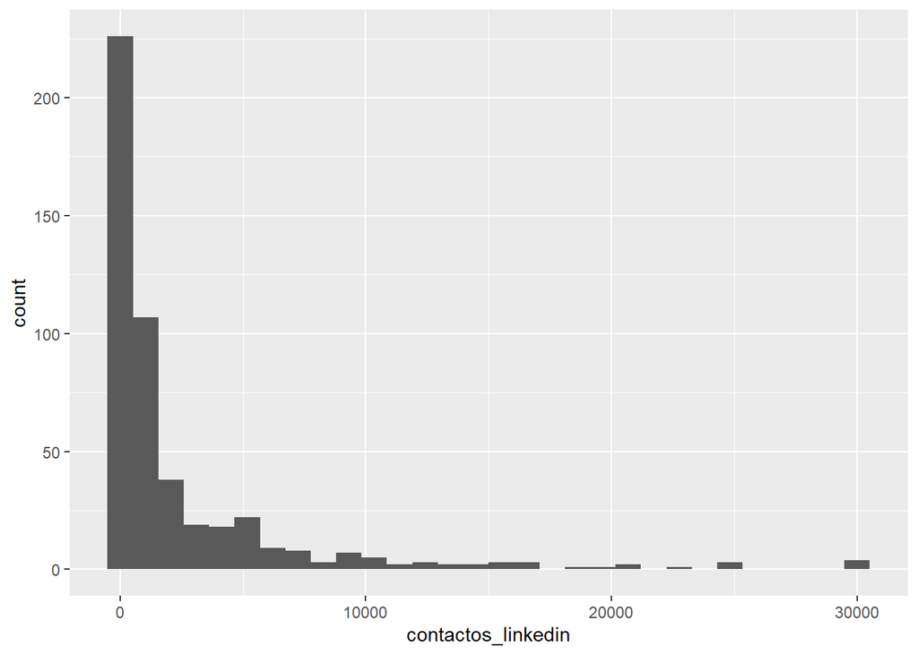

```r
ggplot(contactos,                       # Nombre del data frame
       aes(x = contactos_linkedin)) +   # Variable que mapeamos en el eje x
  geom_histogram()                      # Tipo de gráfico
```

En R hay más de una forma de hacer las cosas. Por ejemplo, usando el paquete `summarytools` podemos crear los grupos de manera más rápida con la función `cut()` y con el parámetro `breaks` le indicamos la cantidad de grupos que queremos.

A continuación vamos a crear 5 grupos (`breaks = 5`) dividiendo en partes iguales a cada grupo. Lo que hace R con esto es tomar todo el rango de valores de la variable numérica y crea cinco secciones iguales.

```r
# Creamos una columna nueva para asignar los grupos
contactos$grupo <- cut(contactos$contactos_linkedin,
                       breaks = 5) # Crea 5 grupos

# Calculamos las frecuencias por grupo
freq(contactos$grupo,
     report.nas = FALSE)
```

```
## Frequencies
## contactos$grupo
## Type: Factor
##
##                           Freq        %   % Cum.
## ----------------------- ------ -------- --------
##             (-30,6e+03]    433    88.55    88.55
##         (6e+03,1.2e+04]     34     6.95    95.50
##       (1.2e+04,1.8e+04]     10     2.04    97.55
##       (1.8e+04,2.4e+04]      5     1.02    98.57
##         (2.4e+04,3e+04]      7     1.43   100.00
##                   Total    489   100.00   100.00
```

En ocasiones R, para simplificar la cantidad de ceros de una salidad de un cálculo utiliza una codificación para indicar la cantidad de ceros que tiene el resultado..

En los ejemplos podemos ver que tenemos un 6<sup>e+03</sup> lo que equivale a un *6* seguidos por 3 posiciones de ceros. Los restantes resultados se interpretan de la siguiente manera.

- 1.2<sup>e+04</sup> = 12.000
- 1.8<sup>e+04</sup> = 18.000
- 2.4<sup>e+04</sup> = 24.000
- 3<sup>e+04</sup> = 30.000

Como en R hay más de una forma de hacer las cosas, siempre vamos a estar tomando decisiones entre obtener lo que queremos más rápido y con pocas líneas de código como vimos anteriormente, o bien, dedicar un poco más de esfuerzo en la preparación y limpieza para obtener algo más simple de entender después.

Otra forma de distribuir los resultados en categorías es usando un par de funciones de `tidyverse`. En esta opción estamos creando categorías en base a un criterio arbitrario.

```r
contactos_2 <- contactos %>%
  mutate(rango_contactos = case_when(          # Para crear categorías según el valor
    contactos_linkedin < 500   ~ "Hasta 500",          # Grupo 1
    contactos_linkedin < 2500  ~ "Entre 500 y 2500",   # Grupo 2
    contactos_linkedin < 5000  ~ "Entre 2500 y 5000",  # Grupo 3
    contactos_linkedin < 10000 ~ "Entre 5000 y 10000", # Grupo 4
    contactos_linkedin = T ~ "Más de 10000"            # Grupo 5
  ),
  rango_contactos = factor(rango_contactos,
                           levels = c("Hasta 500", "Entre 500 y 2500",
                                      "Entre 2500 y 5000", "Entre 5000 y 10000",
                                      "Más de 10000"))) # Este es un paso necesario para que los grupos queden mejor ordenados.
```

Y ahora podemos calcular los rangos de frecuencia:

```r
contactos_2 %>%
  select(rango_contactos) %>%
  freq(report.nas = FALSE)
```

```
## Frequencies
## contactos_2$rango_contactos
## Type: Factor
##
##                            Freq        %   % Cum.
## ------------------------ ------ -------- --------
##                Hasta 500    174    35.58    35.58
##         Entre 500 y 2500    190    38.85    74.44
##        Entre 2500 y 5000     47     9.61    84.05
##       Entre 5000 y 10000     46     9.41    93.46
##             Más de 10000     32     6.54   100.00
##                    Total    489   100.00   100.00
```

# Gráficos

## Gráfico de barras

En la Encuesta KIWI se le preguntó a las personas que les exigieron saber un idioma para ser contratadas, qué porcentaje de su jornada, emplean ese idioma en su trabajo actual.

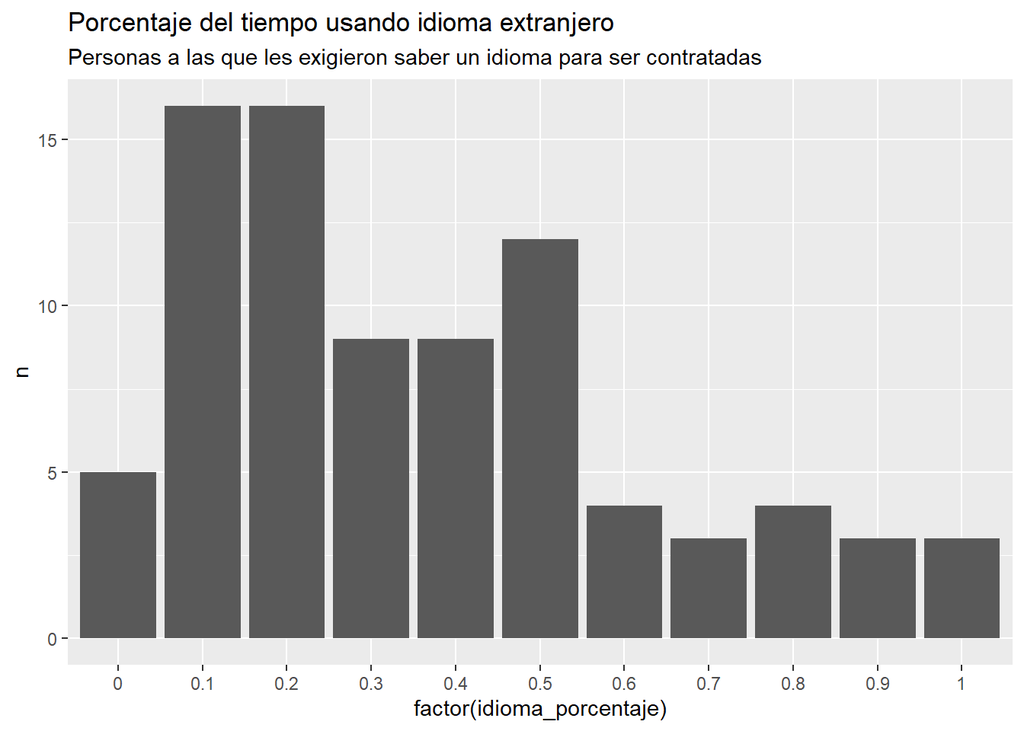

```r
# Preparación de los datos
idioma <- kiwi %>%                      # Creamos un nuevo data frame
  filter(!is.na(idioma_porcentaje),     # Filtro las respuestas nulas
         idioma_exigencia == "Si") %>%  # Filtro por las personas que sí les exigieron un idioma extranjero para entrar en su trabajo actual
  count(idioma_porcentaje)              # Cuenta la frecuencia por respuestas

# Realizo el gráfico
ggplot(idioma,                            # Cargo el data frame
       aes(x = factor(idioma_porcentaje), # Con factor() logro mostrar todas las etiquetas del eje
           y = n)) +                      # mapeo la columna n al eje y
  geom_col() +                            # Tipo de gráfico
  # Agrega título y subtítulo al gráfico
  labs(title = "Porcentaje del tiempo usando idioma extranjero",
       subtitle = "Personas a las que les exigieron saber un idioma para ser contratadas")
```

## Histogramas

Los *histogramas* son gráficos que permiten conocer la distribución de una *variable numérica*.

Para realizar nuestro histograma vamos a utilizar la columna `sueldo_bruto` de la Encuesta KIWI. Hagamos el gráfico.

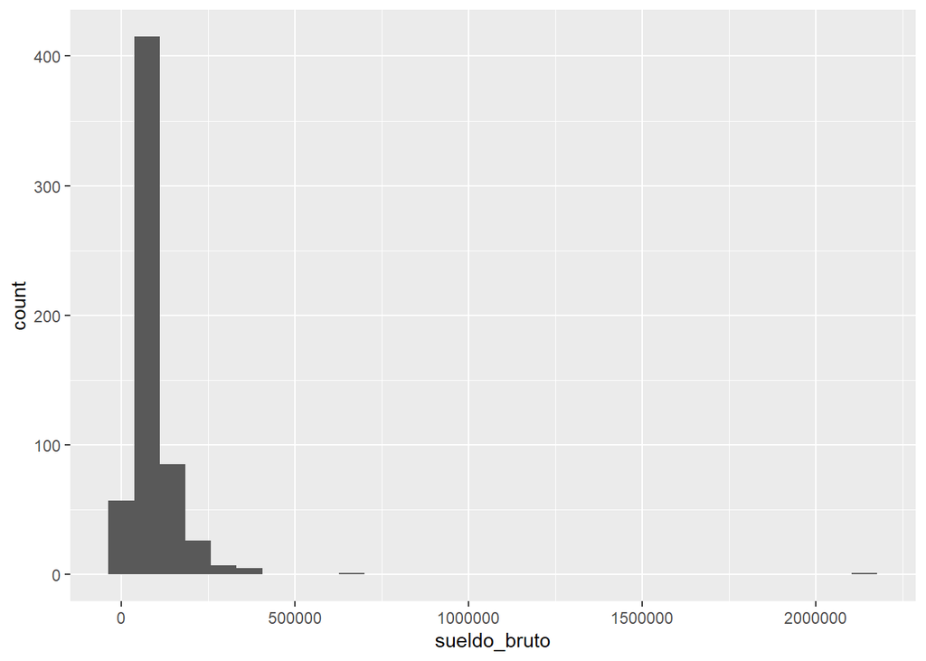

```r
ggplot(kiwi, aes(x = sueldo_bruto)) +
  geom_histogram()
```

Nos sale un gráfico horrible porque la presencia de valores **outliers** nos está “ensuciando” el gráfico. Exploremos esta variable:

```r
summary(kiwi$sueldo_bruto)
```

```
##    Min. 1st Qu.  Median    Mean 3rd Qu.    Max.
##       0   52000   72000   90638  102000 2140000
```

Acá podemos percibir que el valor mínimo es $ 0. Y que el valor máximo es $ 2.140.000. Así que tenemos que buscar la forma de limpiar estos valores.

Una forma elegante de resolver este problema es buscando los valores que se encuentren entre los percentiles 5 y 95. En otras palabras vamos a hacer una **poda** de los extremos de la variable. Para ello vamos a usar un paquete que se llama `funModeling` y la función `profiling_num`

```r
# Creamos un objeto con los resultados de la función
limpieza <- profiling_num(kiwi$sueldo_bruto)

# Veamos los valores almacenados
limpieza
```

```
##   variable     mean std_dev variation_coef  p_01  p_05  p_25  p_50   p_75
## 1      var 90637.72  104064       1.148131 94.56 29320 52000 72000 102000
##     p_95   p_99 skewness kurtosis   iqr        range_98        range_80
## 1 210000 338480 13.37752 254.8833 50000 [94.56, 338480] [37000, 150000]
```

Con esta función puedo saber que el sueldo en el percentil 5 es 29320 y que el valor en el percentil 95 es 210000. Ahora puedo eliminar los valores que estén por debajo y por encima de esos percentiles para quedarme con las muestras más representativas.

Exploremos como quedan los valores ahora.

```r
# Creo objetos almacenando los valores de los percentiles 5 y 95
p05 <- limpieza[1,6]
p95 <- limpieza[1,10]

# Creo un nuevo data frame llamado 'sueldos'
sueldos <- kiwi %>%
  filter(tipo_contratacion != "Part time",  # Filtro los que no sean Part time
         between(sueldo_bruto,              # Variable a filtrar con 'between'
                 p05,                       # Filtro inferior
                 p95))                      # Filtro superior

# Exploremos la variable sueldo_bruto después de los filtros
summary(sueldos$sueldo_bruto)
```

```
##    Min. 1st Qu.  Median    Mean 3rd Qu.    Max.
##   29400   55000   73000   82422  100000  210000
```

Y ahora, con los datos limpios, probemos nuevamente de realizar nuestro histograma:

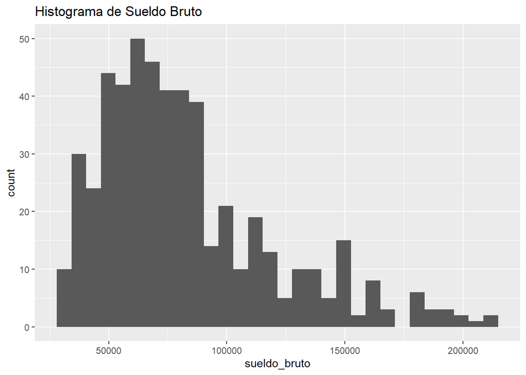

```r
ggplot(sueldos, aes(x = sueldo_bruto)) +
  geom_histogram() +
  ggtitle("Histograma de Sueldo Bruto")
```

Ahora quedó algo con más onda 😎

## Polígono de frecuencia

Los polígonos de frecuencia son una capa adicional que se puede agregar a los histogramas para añadir más información sobre la distribución.

Un detalle a tener en cuenta es que la cantidad de `bins` tiene que ser idéntica a la del histograma

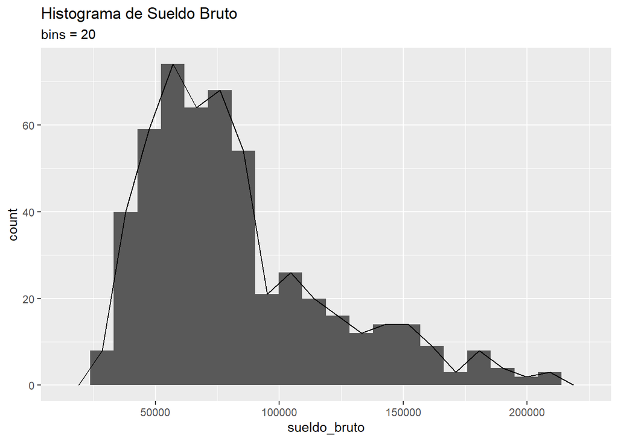

```r
# Histograma con Polígono de Frecuencias
ggplot(sueldos, aes(x = sueldo_bruto)) +
  geom_histogram(bins = 20) +                 # Modificamos la cantidad de grupos del histograma
    geom_freqpoly(aes(sueldo_bruto),          # Añadimos el polígono de frecuencia
                bins = 20) +
  labs(title = "Histograma de Sueldo Bruto",  # Agrega titulo y subtítulo
       subtitle = "bins = 20")
```

## Series de tiempo

Para esto usaremos una muestra de los datos de ingreso del dataframe `plantel` para ver la cantidad de personas contratradas por años desde el 2011 en adelante

```r
# Creamos un nuevo dataframe filtrando los ingresos posteriores al 2010
ingresos <- plantel %>%
  filter(year(fecha_ingreso) > 2010)

# Contamos la cantidad de ingresos por año
ingresos <- ingresos %>%
  count(anio_ingreso)

# Veamos los resultados
ingresos
```

```
## # A tibble: 10 x 2
##    anio_ingreso            n
##    <dttm>              <int>
##  1 2011-01-01 00:00:00   209
##  2 2012-01-01 00:00:00   190
##  3 2013-01-01 00:00:00   419
##  4 2014-01-01 00:00:00   299
##  5 2015-01-01 00:00:00   384
##  6 2016-01-01 00:00:00   327
##  7 2017-01-01 00:00:00   376
##  8 2018-01-01 00:00:00   384
##  9 2019-01-01 00:00:00   597
## 10 2020-01-01 00:00:00   518
```

Con estos datos, ahora podemos hacer nuestro gráfico:

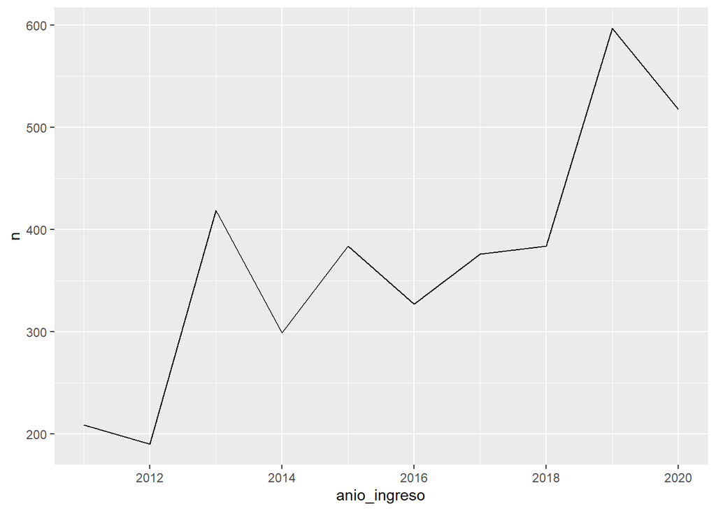

```r
ggplot(ingresos, aes(x = anio_ingreso, y = n)) +
  geom_line()
```

## Gráficos de torta

Los gráficos de torta no son tan sencillos de hacer en R. En esencia lo que tenemos que hacer es un gráfico de barras apilado al 100% y luego doblarlo para hacer el gráfico de torta o de dona.

Cuando tienen pocas categorías (no más de 4 o 5 a lo sumo), los gráficos de torta son muy fáciles de interpretar.

Vamos a graficar de la Encuesta KIWI, cuántos participantes fueron a universidades públicas, privadas, y cuántos no fueron a la universidad. Primero creamos el dataframe

```r
educ <- kiwi %>%
  select(tipo_universidad) %>%    # Seleccionamos la columna tipo universidad
  group_by(tipo_universidad) %>%  # Agrupamos los resultados
  summarise (n = n()) %>%         # Contamos la cantidad de casos para cada grupo
  mutate(freq = n/sum(n)) %>%     # Creamos una columna nueva calculando la frecuencia relativa
  arrange(-n)                     # Ordenamos los resultados de mayor a menor

educ
```

```
## # A tibble: 3 x 3
##   tipo_universidad                 n   freq
##   <chr>                        <int>  <dbl>
## 1 Universidad Pública            296 0.496
## 2 Universidad Privada            278 0.466
## 3 No estudié en la Universidad    23 0.0385
```

Luego hay que computar los valores mínimos y máximos de cada rectángulo (recuerden que primero tenemos que hacer una barra.

```r
# Calcular los porcentajes acumulados (tope de cada rectángulo)
educ$ymax <- cumsum(educ$freq)

# Calcula el límite inferior
educ$ymin <- c(0, head(educ$ymax, n=-1))

educ
```

```
## # A tibble: 3 x 5
##   tipo_universidad                 n   freq  ymax  ymin
##   <chr>                        <int>  <dbl> <dbl> <dbl>
## 1 Universidad Pública            296 0.496  0.496 0
## 2 Universidad Privada            278 0.466  0.961 0.496
## 3 No estudié en la Universidad    23 0.0385 1     0.961
```

Y ahora podemos hacer el gráfico. Este es el gráfico que tenemos que “doblar”.

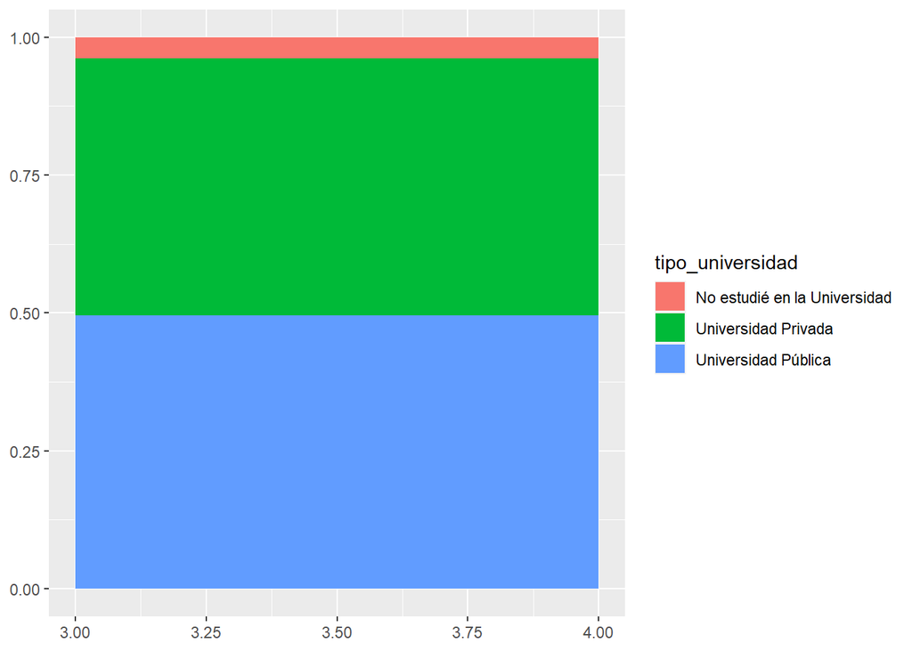

```r
ggplot(educ, aes(ymax=ymax, ymin=ymin, xmax=4, xmin=3, fill=tipo_universidad)) +
  geom_rect()
```

Y ahora sí, podemos hacer el gráfico de dona.

[figure not shown]

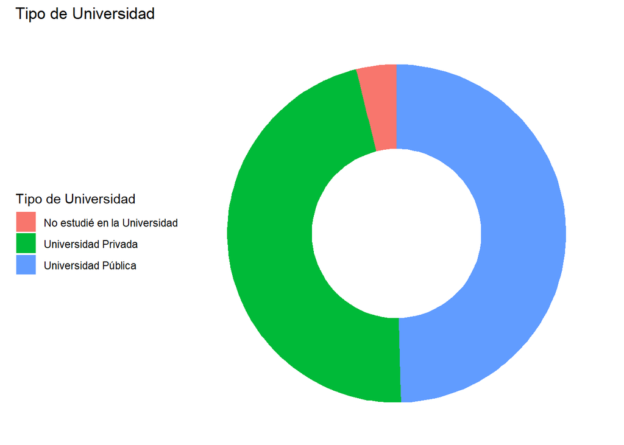

```r
# Hacemos el gráfico
ggplot(educ, aes(ymax=ymax, ymin=ymin, xmax=4, xmin=3, fill=tipo_universidad)) +
  geom_rect() +
  coord_polar(theta="y") + # Elimina esta línea de código para entender lo que hace R.
  xlim(c(2, 4)) + # Prueben eliminando esta línea de código para hacer un gráfico de torta
  theme_void() +                             # Cambia estética del gráfico
  theme(legend.position = "left",            # Cambia la posición de la leyenda
        plot.title.position = "plot") +      # Cambia la posición del título
  labs(title = "Tipo de Universidad",
       fill = "Tipo de Universidad")
```

### Más información

El capítulo 2 del libro [Un Recorrido por los Métodos Cuantitativos en Ciencias Sociales a bordo de R](https://estadisticacienciassocialesr.rbind.io/distribuciones-de-frecuencia.html#tablas-univariadas) de Eduardo Bologna habla sobre **frecuencias**.

Para el tema de limpieza de datos, tenemos una [introducción a tidyverse](https://youtu.be/-AXzusX4Cmo) que hicimos en el Club de R.

Sobre visualización de datos tenemos el siguiente contenido:

[Introducción a ggplot2](https://youtu.be/IdJ1UuEcCV8)

[Estética de visualización](https://youtu.be/Z2cGkNh1mVM)

[Microaprendizajes](https://youtu.be/lntmPdo8nbk) (pequeños tips sobre visualización de datos y otras cosas más).

Algunos documentos complementarios:

[Introducción a R](https://docs.google.com/document/d/1KCcrMDdEhp-4tw036DiNZqUGxMdBqztJ4Bfihqf4QUw/edit?usp=sharing)

[Introducción a ggplot2](https://docs.google.com/document/d/1JAthc42Hno3tIhvZRrjA02zRCdS8q2uixODCBaZcPJ0/edit?usp=sharing)